# Cipla stock time series analysis

Disha Patel- 10A

================================================

##### **Downloading and loading relevant packages**

================================================

```r
packages = c('tseries', 'forecast', 'FinTS', 'rugarch', 'quantmod')
lapply(packages, require, character.only = TRUE)
```

```
## [[1]]
## [1] TRUE
##
## [[2]]
## [1] TRUE
##
## [[3]]
## [1] TRUE
##
## [[4]]
## [1] TRUE
##
## [[5]]
## [1] TRUE
```

==========================================

##### **Loading stock price data from Yahoo**

===========================================

```r
getSymbols(Symbols = 'CIPLA.NS',
           src = 'yahoo',
           from = as.Date('2019-01-01'),
           to = as.Date('2022-12-31'),
           periodicity = 'daily')
```

```
## [1] "CIPLA.NS"
```

==================================

##### **Removing NA values from data**

===================================

```r
cipla_price = na.omit(CIPLA.NS$CIPLA.NS.Adjusted)
class(cipla_price)
```

```
## [1] "xts" "zoo"
```

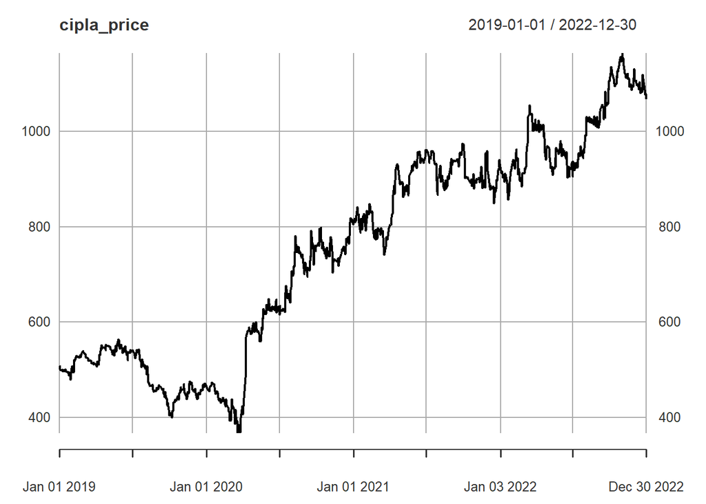

```r
plot( cipla_price)
```

=============================================

#### **ADF test for price to check stationarity**

==============================================

###### **Objective** : To load stock price dataset and check for its stationarity

###### **Analysis** : Extracted stock price data and checked for stationarity; H0 : Price is not stationary

###### **Results** : Null hypothesis is accepted; p-value = 0.277

###### **Managerial implication** : Stock price of Cipla is not stationary in the given time period and thus returns needs to be calculated

```r
adf_test_cipla_price = adf.test(cipla_price)
adf_test_cipla_price
```

```
##
##  Augmented Dickey-Fuller Test
##
## data:  cipla_price
## Dickey-Fuller = -2.7118, Lag order = 9, p-value = 0.277
## alternative hypothesis: stationary
```

========================================

#### **Obtaining cipla stock return price**

=========================================

#### **ADF test for price to check stationarity**

###### **Objective** : To obtain returns from stock price dataset and check for its stationarity

###### **Analysis** : Extracted return, visualised and checked for stationarity; H0 : Price is not stationary

###### **Results** : Null hypothesis is rejected; p-value = 0.01

###### **Managerial implication** : Returns of Cipla is stationary in the given time period.

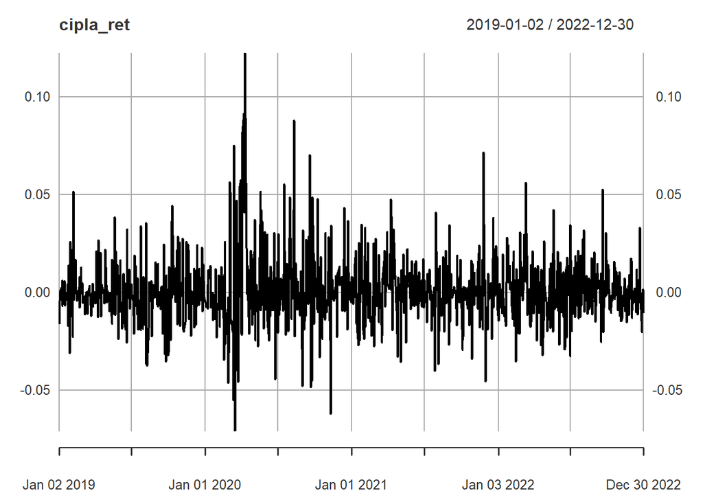

```r
cipla_ret =na.omit(diff(log(cipla_price)))
plot(cipla_ret)
```

```r
adf_test_cipla = adf.test(cipla_ret)
adf_test_cipla
```

```
##
##  Augmented Dickey-Fuller Test
##
## data:  cipla_ret
## Dickey-Fuller = -9.4492, Lag order = 9, p-value = 0.01
## alternative hypothesis: stationary
```

========================================================

#### **Checking for autocorrelation using Ljung-Box Test**

===========================================================

###### **Objective** : To check for presence of autocorrelation in the returns dataset.

###### **Analysis** : Performed Box-Pierce test,to assess the presence of autocorrelation in cipla returns dataset

###### **Results** : Null hypothesis is rejected; p-value = 0.03651; H0: Autocorrelation is absent

###### **Managerial implication** : Statistically significant autocorrelation present in the returns of the Cipla stock, there is a pattern or relationship between the returns at different time periods, which could be important for further analysis or modeling of the data

```r
lb_test_cipla_ds = Box.test(cipla_ret)
lb_test_cipla_ds
```

```
##
##  Box-Pierce test
##
## data:  cipla_ret
## X-squared = 4.3731, df = 1, p-value = 0.03651
```

=============================

#### **Modelling for ARIMA**

==============================

###### **Plotting ACF and PACF plots to determine lag value**

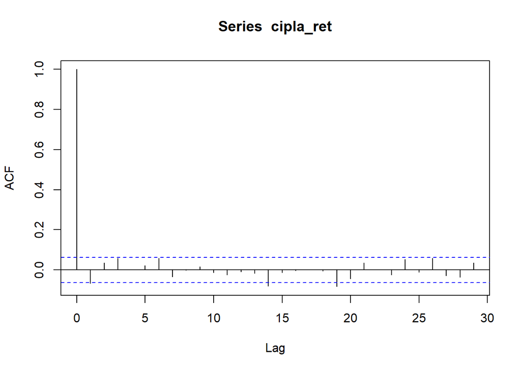

```r
acf(cipla_ret)
```

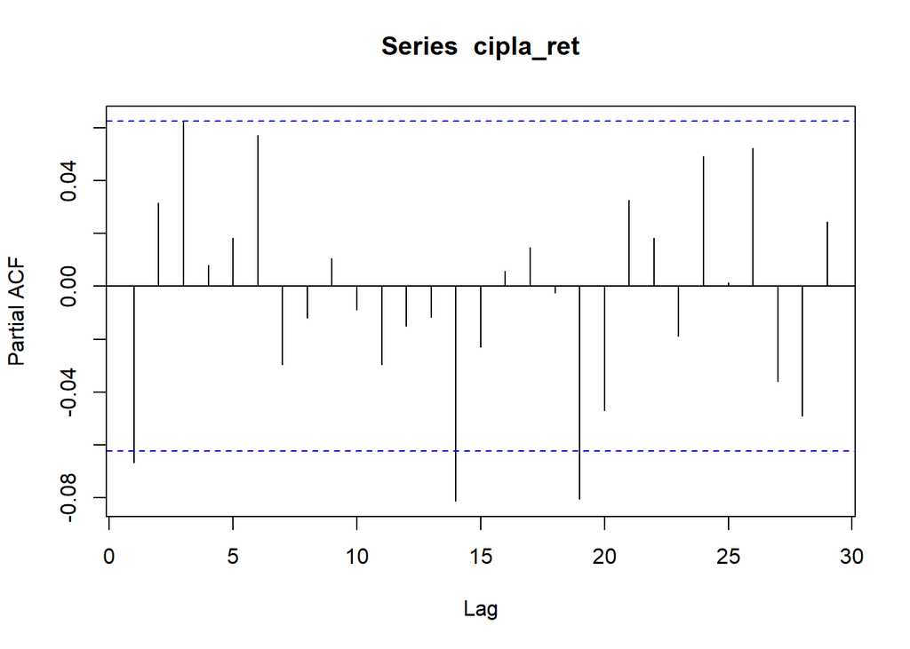

```r
pacf(cipla_ret)
```

###### **MA order**: ACF cuts off after 0 lags

=====================================

##### **Using auto - ARIMA**

======================================

###### **Objective** : To perform autoARIMA modeling on the daily returns of Cipla stock

###### **Analysis** : Used the ‘auto.arima’ function to automatically select the ARIMA model for returns

###### **Results** : The ARIMA model is specified as (1,0,0), indicating that it includes an autoregressive (AR) term of order 1 and no differencing (I) or moving average (MA) terms i.e.

###### AR Order (p-Lags) : p lags = 1;

###### d-Degree of Differencing = 0 (returns price);

###### MA Order (q-Lags): q lags = 0

###### The autoregressive coefficient (ar1) is approximately -0.0665.

###### The mean coefficient (mean) is approximately 8e-04.

###### **Managerial implication** : The negative AR coefficient suggests a negative autocorrelation, indicating that past returns have a negative impact on current returns. The estimated parameters can be used to make predictions about future returns and assess the model’s performance.

###### **Model** : y(t) = 8e - 04 -n0.0665*y(t-1) + e(t)

```r
arma_pq_cipla = auto.arima(cipla_ret)
arma_pq_cipla
```

```
## Series: cipla_ret
## ARIMA(1,0,0) with non-zero mean
##
## Coefficients:
##           ar1   mean
##       -0.0665  8e-04
## s.e.   0.0317  5e-04
##
## sigma^2 = 0.0003125:  log likelihood = 2588.81
## AIC=-5171.62   AICc=-5171.59   BIC=-5156.93
```

##### **Checking ARIMA residuals for autocorrelation using Ljung box test**

```r
lb_test_arma_pq_cipla_ds = Box.test(arma_pq_cipla$residuals)
lb_test_arma_pq_cipla_ds
```

```
##
##  Box-Pierce test
##
## data:  arma_pq_cipla$residuals
## X-squared = 0.0043052, df = 1, p-value = 0.9477
```

###### **Result**: p-value = 0.9477, null hypothesis is accepted, ARIMA model is appropriate, no autocorrelation in residuals

=================================

#### **Forcasting for 40 days**

==================================

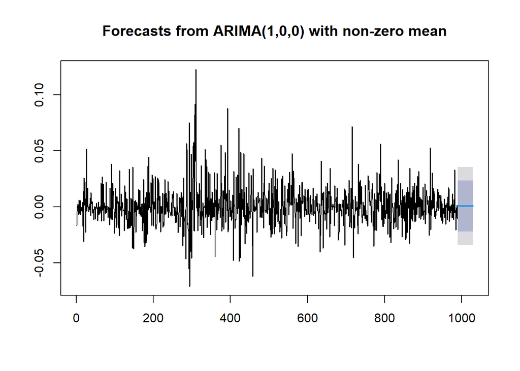

```r
cipla_ds_fpq = forecast(arma_pq_cipla, h = 40)
plot(cipla_ds_fpq)
```

#### **Squaring ARIMA residuals and checking for autocorrelation**

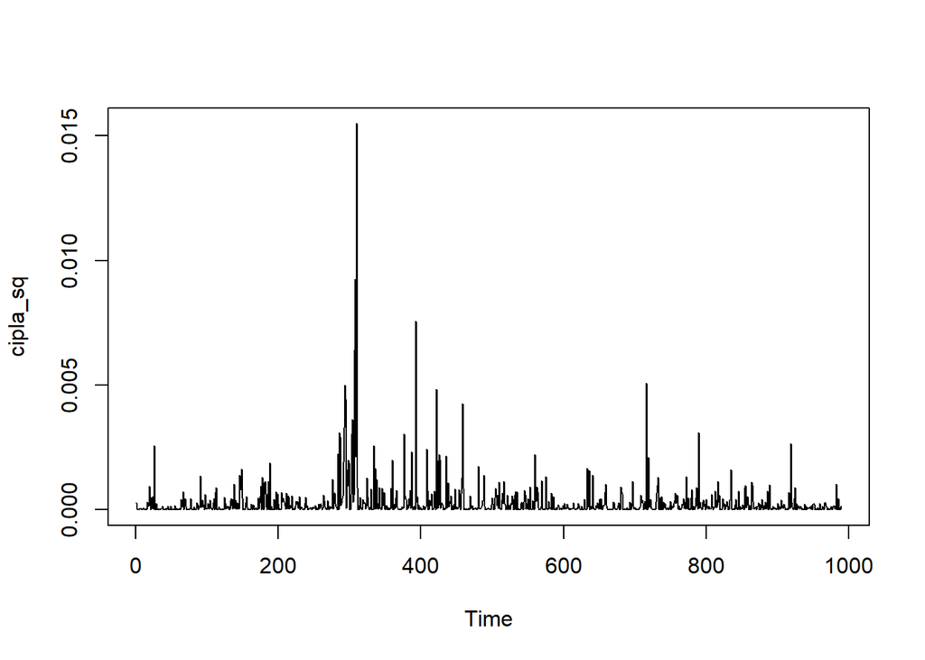

```r
cipla_sq = arma_pq_cipla$residuals^2
plot(cipla_sq)
```

```r
cipla_ret_sq_box_test = Box.test(cipla_sq, lag = 10)
cipla_ret_sq_box_test
```

```
##
##  Box-Pierce test
##
## data:  cipla_sq
## X-squared = 234.11, df = 10, p-value < 2.2e-16
```

==============================================================

#### **Checking for Heteroskedasticity using ARCH LM test**

===============================================================

###### **Objective** : To test for volatility clustering or heteroskedasticity in the residuals of the ARIMA(1, 0, 0) model

###### **Analysis** : Conducted Box test and ARCH test on the squared residuals to assess the presence of volatility clustering

###### **Results** : Null hypothesis is rejected; p-value = 0.01419; H0: No heteroskedasticity present

###### **Managerial implication** : There are significant ARCH effects present in the returns of the Cipla stock. In other words, the variance of the returns is not constant over time, indicating that the volatility of the stock’s returns varies over time.

```r
cipla_arch_test = ArchTest(cipla_sq, lags = 1)
cipla_arch_test
```

```
##
##  ARCH LM-test; Null hypothesis: no ARCH effects
##
## data:  cipla_sq
## Chi-squared = 6.0147, df = 1, p-value = 0.01419
```

==========================

#### **Modelling for GARCH**

==========================

###### **Objective** : To fit GARCH models to the residuals of the ARIMA(1, 0, 0) model and test for volatility clustering.

###### **Analysis** : Fitted two GARCH models and conducted ARCH test on residuals

###### **Results** : Since the p-value (0.102) is greater than the typical significance level of 0.05, we fail to reject the null hypothesis. This means that there is not enough evidence to conclude that there are ARCH effects present in the squared residuals at a significance level of 0.05

###### **Managerial implication** :The result suggests that the squared residuals from the GARCH model do not exhibit significant conditional heteroskedasticity. Therefore, the volatility clustering or conditional heteroskedasticity patterns in the data might be adequately captured by the current GARCH model

```r
garch_model1 = ugarchspec(variance.model = list(model = 'sGARCH', garchOrder = c(1,1)), mean.model = list(armaOrder = c(0,0), include.mean = TRUE))
cipla_ret_garch1 = ugarchfit(garch_model1, data = cipla_ret);
cipla_ret_garch1
```

```
##
## *---------------------------------*
## *          GARCH Model Fit        *
## *---------------------------------*
##
## Conditional Variance Dynamics
## -----------------------------------
## GARCH Model  : sGARCH(1,1)
## Mean Model   : ARFIMA(0,0,0)
## Distribution : norm
##
## Optimal Parameters
## ------------------------------------
##         Estimate  Std. Error  t value Pr(>|t|)
## mu      0.000511    0.000479   1.0669    0.286
## omega   0.000015    0.000002   8.2523    0.000
## alpha1  0.098120    0.012051   8.1423    0.000
## beta1   0.855639    0.016434  52.0641    0.000
##
## Robust Standard Errors:
##         Estimate  Std. Error  t value Pr(>|t|)
## mu      0.000511    0.000436   1.1729 0.240847
## omega   0.000015    0.000003   4.8303 0.000001
## alpha1  0.098120    0.018379   5.3386 0.000000
## beta1   0.855639    0.023568  36.3046 0.000000
##
## LogLikelihood : 2664.15
##
## Information Criteria
## ------------------------------------
##
## Akaike       -5.3795
## Bayes        -5.3597
## Shibata      -5.3795
## Hannan-Quinn -5.3719
##
## Weighted Ljung-Box Test on Standardized Residuals
## ------------------------------------
##                         statistic  p-value
## Lag[1]                      8.726 0.003137
```

[output cut: 37 more lines]

```
## Negative Sign Bias  1.7490 0.0806   *
## Positive Sign Bias  0.6297 0.5290
## Joint Effect        3.4646 0.3254
##
##
## Adjusted Pearson Goodness-of-Fit Test:
## ------------------------------------
##   group statistic p-value(g-1)
## 1    20     85.20    2.327e-10
## 2    30     98.01    2.034e-09
## 3    40    103.13    1.064e-07
## 4    50    118.13    1.223e-07
##
##
## Elapsed time : 0.1521511
```

```r
garch_model2 = ugarchspec(variance.model = list(model = 'sGARCH', garchOrder = c(1,1)), mean.model = list(armaOrder = c(1,1), include.mean = FALSE))
cipla_ret_garch2 = ugarchfit(garch_model2, data = cipla_ret);
cipla_ret_garch2
```

```
##
## *---------------------------------*
## *          GARCH Model Fit        *
## *---------------------------------*
##
## Conditional Variance Dynamics
## -----------------------------------
## GARCH Model  : sGARCH(1,1)
## Mean Model   : ARFIMA(1,0,1)
## Distribution : norm
##
## Optimal Parameters
## ------------------------------------
##         Estimate  Std. Error  t value Pr(>|t|)
## ar1    -0.091584    0.206324 -0.44388  0.65713
## ma1    -0.021873    0.205721 -0.10633  0.91532
## omega   0.000015    0.000003  5.88749  0.00000
## alpha1  0.101910    0.012911  7.89323  0.00000
## beta1   0.848765    0.016680 50.88650  0.00000
##
## Robust Standard Errors:
##         Estimate  Std. Error  t value Pr(>|t|)
## ar1    -0.091584    0.138672 -0.66044 0.508973
## ma1    -0.021873    0.133825 -0.16345 0.870166
## omega   0.000015    0.000005  2.95497 0.003127
## alpha1  0.101910    0.022609  4.50746 0.000007
## beta1   0.848765    0.028771 29.50075 0.000000
##
## LogLikelihood : 2668.855
##
## Information Criteria
## ------------------------------------
##
## Akaike       -5.3870
## Bayes        -5.3622
## Shibata      -5.3870
## Hannan-Quinn -5.3776
##
## Weighted Ljung-Box Test on Standardized Residuals
## ------------------------------------
```

[output cut: 40 more lines]

```
## Negative Sign Bias  1.6523 0.09879   *
## Positive Sign Bias  0.6526 0.51419
## Joint Effect        3.1597 0.36765
##
##
## Adjusted Pearson Goodness-of-Fit Test:
## ------------------------------------
##   group statistic p-value(g-1)
## 1    20     76.86    6.414e-09
## 2    30     95.64    4.815e-09
## 3    40     95.37    1.267e-06
## 4    50    111.05    1.025e-06
##
##
## Elapsed time : 0.102174
```

```r
arima_model <- arima(cipla_ret, order = c(1,0,0))
arima_residuals <- residuals(arima_model)
garch_spec <- ugarchspec(variance.model = list(model = 'sGARCH', garchOrder = c(1,1)),
                         mean.model = list(armaOrder = c(0,0), include.mean = FALSE))
garch_fit <- ugarchfit(garch_spec, data = arima_residuals^2)
arch_lm_test <- ArchTest(residuals(garch_fit)^2, lags = 10)
print("ARCH LM-test for squared residuals of GARCH model:")
```

```
## [1] "ARCH LM-test for squared residuals of GARCH model:"
```

```r
print(arch_lm_test)
```

```
##
##  ARCH LM-test; Null hypothesis: no ARCH effects
##
## data:  residuals(garch_fit)^2
## Chi-squared = 15.917, df = 10, p-value = 0.102
```

```r
cipla_ret_garch_forecast1 = ugarchforecast(cipla_ret_garch1, n.ahead = 50);
cipla_ret_garch_forecast1
```

```
##
## *------------------------------------*
## *       GARCH Model Forecast         *
## *------------------------------------*
## Model: sGARCH
## Horizon: 50
## Roll Steps: 0
## Out of Sample: 0
##
## 0-roll forecast [T0=2022-12-30]:
##         Series   Sigma
## T+1  0.0005113 0.01391
## T+2  0.0005113 0.01411
## T+3  0.0005113 0.01430
## T+4  0.0005113 0.01447
## T+5  0.0005113 0.01464
## T+6  0.0005113 0.01480
## T+7  0.0005113 0.01495
## T+8  0.0005113 0.01509
## T+9  0.0005113 0.01522
## T+10 0.0005113 0.01534
## T+11 0.0005113 0.01546
## T+12 0.0005113 0.01557
## T+13 0.0005113 0.01568
## T+14 0.0005113 0.01578
## T+15 0.0005113 0.01588
## T+16 0.0005113 0.01597
## T+17 0.0005113 0.01605
## T+18 0.0005113 0.01613
## T+19 0.0005113 0.01621
## T+20 0.0005113 0.01628
## T+21 0.0005113 0.01635
## T+22 0.0005113 0.01642
## T+23 0.0005113 0.01648
## T+24 0.0005113 0.01654
## T+25 0.0005113 0.01660
## T+26 0.0005113 0.01665
## T+27 0.0005113 0.01670
## T+28 0.0005113 0.01675
## T+29 0.0005113 0.01680
## T+30 0.0005113 0.01684
## T+31 0.0005113 0.01688
## T+32 0.0005113 0.01692
## T+33 0.0005113 0.01696
## T+34 0.0005113 0.01700
## T+35 0.0005113 0.01703
## T+36 0.0005113 0.01706
## T+37 0.0005113 0.01710
## T+38 0.0005113 0.01713
## T+39 0.0005113 0.01715
## T+40 0.0005113 0.01718
## T+41 0.0005113 0.01721
## T+42 0.0005113 0.01723
## T+43 0.0005113 0.01725
## T+44 0.0005113 0.01728
## T+45 0.0005113 0.01730
## T+46 0.0005113 0.01732
## T+47 0.0005113 0.01734
## T+48 0.0005113 0.01735
## T+49 0.0005113 0.01737
## T+50 0.0005113 0.01739
```

```r
cipla_ret_garch_forecast2 = ugarchforecast(cipla_ret_garch2, n.ahead = 50); cipla_ret_garch_forecast2
```

```
##
## *------------------------------------*
## *       GARCH Model Forecast         *
## *------------------------------------*
## Model: sGARCH
## Horizon: 50
## Roll Steps: 0
## Out of Sample: 0
##
## 0-roll forecast [T0=2022-12-30]:
##          Series   Sigma
## T+1   1.213e-03 0.01378
## T+2  -1.111e-04 0.01400
## T+3   1.018e-05 0.01420
## T+4  -9.319e-07 0.01439
## T+5   8.535e-08 0.01457
## T+6  -7.817e-09 0.01474
## T+7   7.159e-10 0.01490
## T+8  -6.556e-11 0.01505
## T+9   6.005e-12 0.01519
## T+10 -5.499e-13 0.01532
## T+11  5.037e-14 0.01545
## T+12 -4.613e-15 0.01556
## T+13  4.224e-16 0.01567
## T+14 -3.869e-17 0.01578
## T+15  3.543e-18 0.01588
## T+16 -3.245e-19 0.01597
## T+17  2.972e-20 0.01606
## T+18 -2.722e-21 0.01614
## T+19  2.493e-22 0.01622
## T+20 -2.283e-23 0.01630
## T+21  2.091e-24 0.01637
## T+22 -1.915e-25 0.01643
## T+23  1.754e-26 0.01650
## T+24 -1.606e-27 0.01656
## T+25  1.471e-28 0.01661
## T+26 -1.347e-29 0.01667
## T+27  1.234e-30 0.01672
## T+28 -1.130e-31 0.01677
## T+29  1.035e-32 0.01681
## T+30 -9.478e-34 0.01686
## T+31  8.680e-35 0.01690
## T+32 -7.950e-36 0.01694
## T+33  7.281e-37 0.01697
## T+34 -6.668e-38 0.01701
## T+35  6.107e-39 0.01704
## T+36 -5.593e-40 0.01707
## T+37  5.122e-41 0.01710
## T+38 -4.691e-42 0.01713
## T+39  4.296e-43 0.01716
## T+40 -3.935e-44 0.01719
## T+41  3.604e-45 0.01721
## T+42 -3.300e-46 0.01723
## T+43  3.023e-47 0.01726
## T+44 -2.768e-48 0.01728
## T+45  2.535e-49 0.01730
## T+46 -2.322e-50 0.01731
## T+47  2.126e-51 0.01733
## T+48 -1.948e-52 0.01735
## T+49  1.784e-53 0.01737
## T+50 -1.634e-54 0.01738
```